# Geographic projections and transformations

Robin Lovelace, Jakub Nowosad, Jannes Muenchow

2019-08-07

# Introduction

This workbook outlines key concepts and functions related to map projections — also referred to as coordinate reference systems (CRSs) — and transformation of geographic data from one projection to another. It is based on the open source book *Geocomputation with R*, and Chapter [6](https://geocompr.robinlovelace.net/reproj-geo-data.html) in particular.

It was developed for the ‘[CASA Summer School](https://bonnie-buyuklieva.github.io/SS_ASM19/)’, or the Doctoral Summer School for Advanced Spatial Modelling: Skills Workshop and Hackathon, 21<sup>st</sup> to 23<sup>rd</sup> August 2019, for it’s full name! It should be of use to anyone interested in projections, beyond the summer school, so we posted it on our newly updated [website](https://geocompr.github.io/) for maximum benefit.

# Prerequisites

Before you get started, make sure you have the packages installed:

```r
library(sf)
library(dplyr)
library(spData)
```

# Introduction

Geographic data relies on a frame of reference. There are two main types of CRS:

- Geographic, where the frame of reference is the globe and how many degrees north or east from the position (0, 0) you are
- Projected, where the frame of reference is a flat representation of part of the Earth’s surface

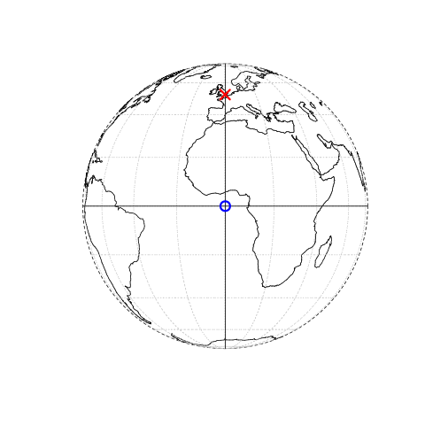

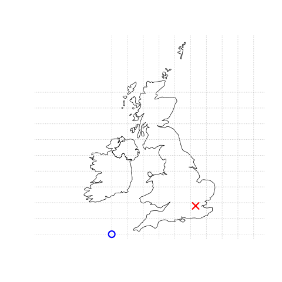

Illustration of vector (point) data in which location of London (the red X) is represented with reference to an origin (the blue circle). The left plot represents a geographic CRS with an origin at 0° longitude and latitude. The right plot represents a projected CRS with an origin located in the sea west of the South West Peninsula.

# TLDR

The ‘too long didn’t read’ (TLDR) take away messages from this lecture are:

- **be aware of projections**
- **decide an appropriate CRS for your project and ensure everything is in that CRS**
- **use a projected CRS when doing geometric operations**
- **there is an officially supported code, called an EPSG code, for most places — that is often a good option**

In R, you can check, set and transform CRS with `st_crs()` and `st_transform()` as follows:

```r
zones_london = lnd
st_crs(zones_london)                                         # find out the CRS
```

```
#> Coordinate Reference System:
#>   EPSG: 4326
#>   proj4string: "+proj=longlat +datum=WGS84 +no_defs"
```

```r
zones_london_projected = st_transform(zones_london, 27700)   # transform CRS
st_crs(zones_london) = NA                                    # set CRS
st_crs(zones_london) = 4326                                  # set CRS
```

If you ignore CRSs, bad things can happen.

# Why are projections needed?

Without a coordinate system, we have no context:

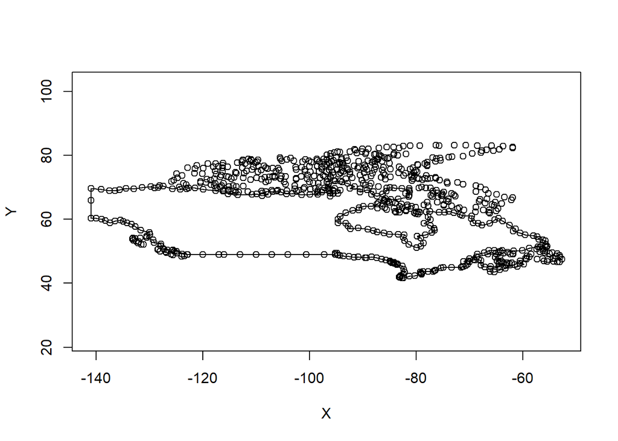

Which country is it?

Location on Earth is measured in degrees so, even when axes are equal, maps are highly distorted representations of reality far from the equator:

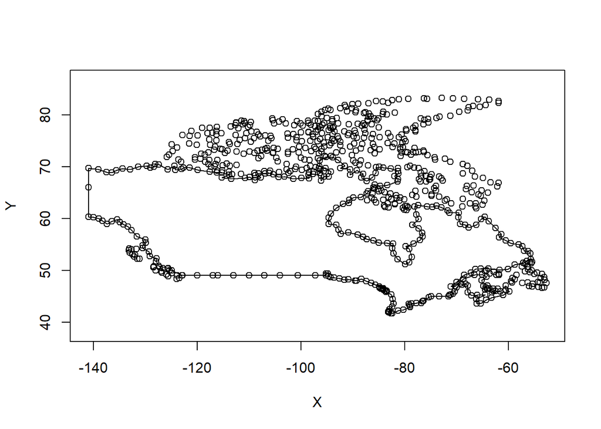

Along which axis is the image over-represented?

Even when we compensate for this, the cylindrical projection is misleading:

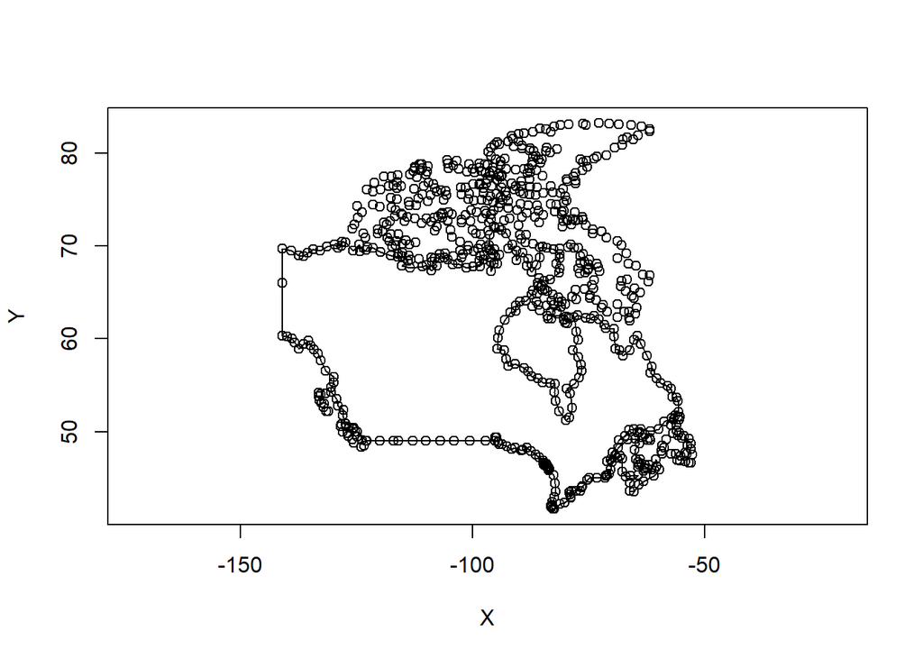

By default, most software (including R) uses a cylindrical projection, leading to maps like this:

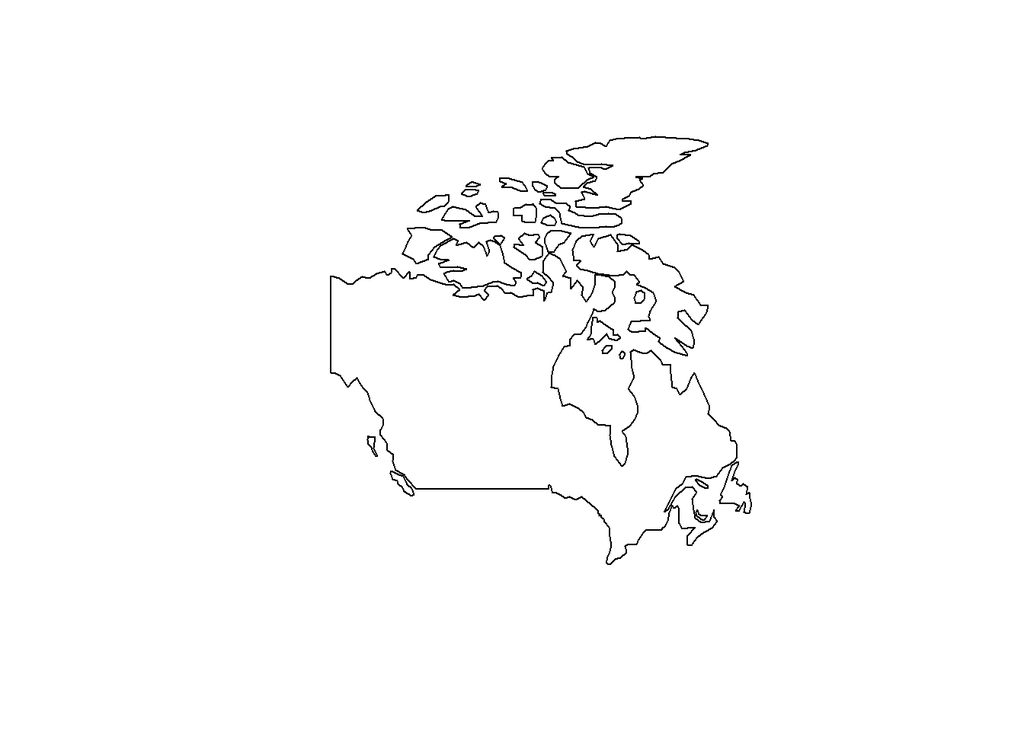

```r
plot(canada$geom)
```

Across the whole world, the results look like this:

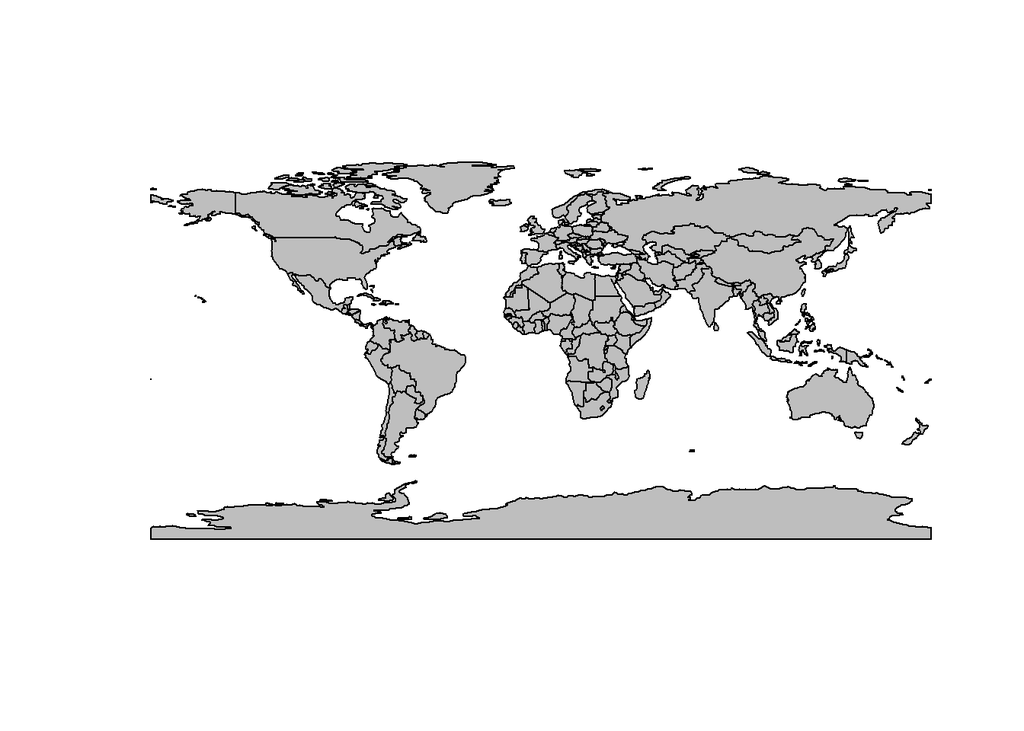

```r
plot(st_geometry(world), col = "grey")
```

There is no single ‘correct’ CRS that can represent everywhere well: it is physically impossible to ‘peal’ the surface of the Earth onto a flat screen (credit: [Awar Jahfar](https://unsplash.com/@awarnerway)):

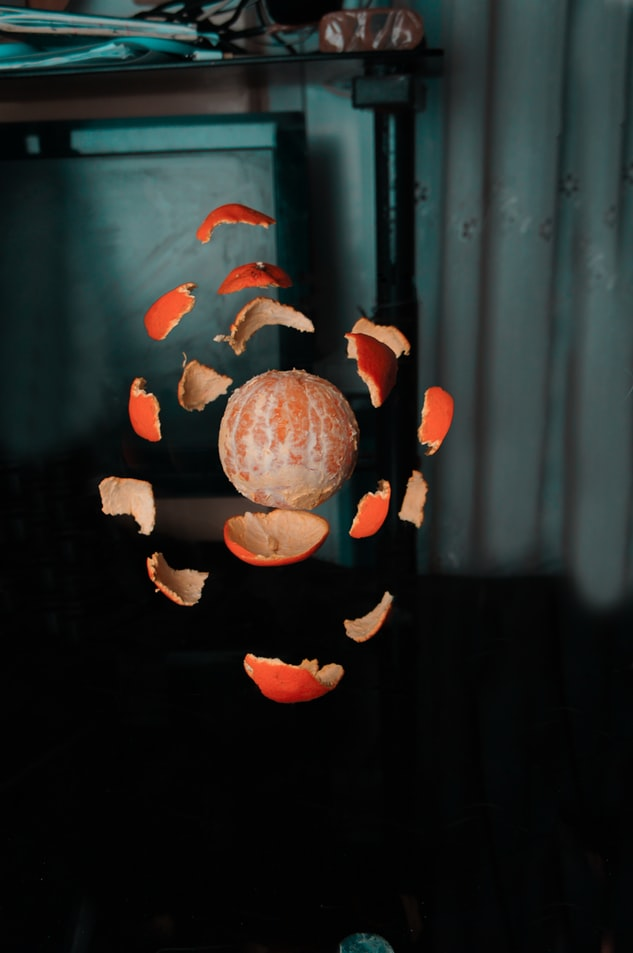

> At best we can comply with two out of three spatial properties (distance, area, direction). Therefore, the task at hand determines which projection to choose. For instance, if we are interested in a density (points per grid cell or inhabitants per grid cell) we should use an equal-area projection.

# Which projection to use?

A range of CRSs is available:

- A Lambert azimuthal equal-area ([LAEA](https://en.wikipedia.org/wiki/Lambert_azimuthal_equal-area_projection)) projection for a custom local projection (set `lon_0` and `lat_0` to the center of the study area), which is an equal-area projection at all locations but distorts shapes beyond thousands of kilometres.
- Azimuthal equidistant ([AEQD](https://en.wikipedia.org/wiki/Azimuthal_equidistant_projection)) projections for a specifically accurate straight-line distance between a point and the centre point of the local projection.
- Lambert conformal conic ([LCC](https://en.wikipedia.org/wiki/Lambert_conformal_conic_projection)) projections for regions covering thousands of kilometres, with the cone set to keep distance and area properties reasonable between the secant lines.
- Stereographic ([STERE](https://en.wikipedia.org/wiki/Stereographic_projection)) projections for polar regions, but taking care not to rely on area and distance calculations thousands of kilometres from the center.

This is how it works in R:

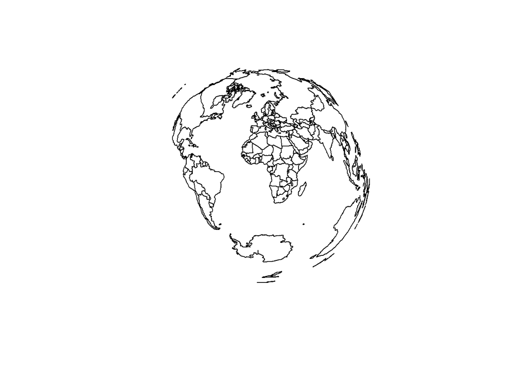

```r
world_laea1_g = world %>%
  st_transform("+proj=laea +x_0=0 +y_0=0 +lon_0=0 +lat_0=0") %>%
  st_geometry()
plot(world_laea1_g)
```

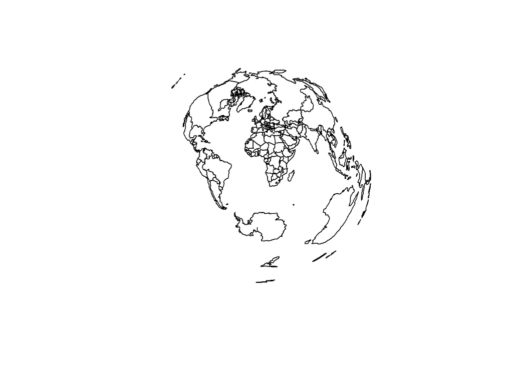

```r
world %>%
  st_transform("+proj=aeqd +x_0=0 +y_0=0 +lon_0=0 +lat_0=0") %>%
  st_geometry() %>%
  plot()
```